# Running `bpp` on sequences from posterior genotype calls

J. Ignacio Lucas Lledó & Mar Llaberia Robledillo

2026-04-15

In `2025-11-06` `bpp` suggested the divergence between the two population is deeper than the average coalescence within any of the two populations. This is at odds with the analyses in `2025-07-09`, where we prove that the effective number of *different* populations was not much larger than 1.0. The previous `bpp` results also contrast with SNAPPER’s analysis, run by Mar either including or excluding the admixed individuals.

## Preparation of data files

In `2025-03-15` we have the following files:

- `toRad.geno`: genotype matrix of RAD loci in 96 samples, coded as *minor* allele count (0, 1 or 2), with the value -1 for missing data.
- `toRef.geno`: genotype matrix of reference-mapped loci in 96 samples.
- `toRad.mafs.gz`: compressed list of RAD loci specifying the alleles present and which one is considered the minor one.
- `toRef.mafs.gz`: same, for reference-mapped loci.
- `bamlist1.txt`: list of BAM files mapped to the reference genome.
- `bamlist2.txt`: list of BAM files mapped to the RAD loci.

We should also take into account the analyisis in `2025-06-12`, where we found several loci suspected to be collapsed paralogous regions. To filter them out, a HWE test was run individually in each population. The inbreeding coefficient *F* reported in the `.hwe.gz` files was used to remove sites where all samples were heterozygous ($F \simeq -1$). I can use those reports, but the goal is to filter full loci, not individual sites, because collapsed paralogy, if real, must be a problem of the whole locus.

### Collapsed paralogous loci revisited

[figure not shown]

```bash
# These are needed to remove collapsed paralogous loci:
if [ ! -e toRef.far.hwe ]; then
   gunzip -c ../2025-06-12/ref/SFS/unfiltered/farionis.hwe.gz > toRef.far.hwe
fi

if [ ! -e toRef.pse.hwe ]; then
   gunzip -c ../2025-06-12/ref/SFS/unfiltered/pseudofarionis.hwe.gz > toRef.pse.hwe
fi

if [ ! -e toRad.far.hwe ]; then
   gunzip -c ../2025-06-12/rad/SFS/unfiltered/farionis.hwe.gz > toRad.far.hwe
fi

if [ ! -e toRad.pse.hwe ]; then
   gunzip -c ../2025-06-12/rad/SFS/unfiltered/pseudofarionis.hwe.gz > toRad.pse.hwe
fi
```

I do not think there is any biological reason for such a relationship between allele frequency and deviation from Hardy-Weinberg equilibrium. Because both parameters were estimated jointly by maximum likelihood with ANGSD, I assume the relationship is an artifact of the method, maybe due to very low coverage. In any case, high MAF sites are a minority. We may not loose much by removing RAD loci containing sites with very negative inbreeding coefficients. The main discontinuity in the ECDF of the minimum *F* value per locus is at the lowest value, which justifies using the same threshold as in `2025-06-12`.

### Filtering of RAD loci

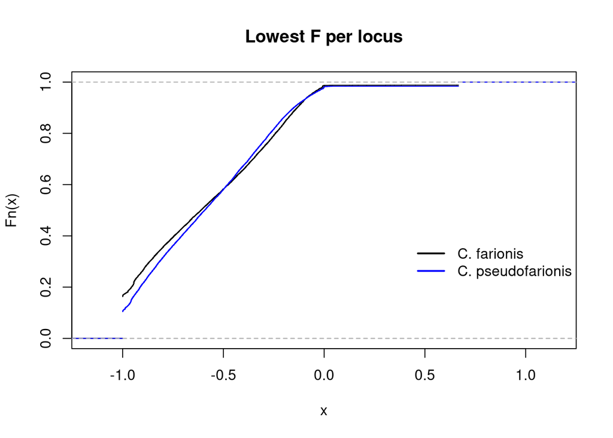

```r
suppressMessages(library('dplyr'))
RadFarSum <- summarise(
   RadFarHwe,
   .by = Chromo,
   MinF   = min(F)
)

RadPseSum <- summarise(
   RadPseHwe,
   .by = Chromo,
   MinF   = min(F)
)

plot(ecdf(RadFarSum$MinF), main = c('Lowest F per locus'))
lines(ecdf(RadPseSum$MinF), col = 'blue')
legend(0.4, 0.4, c('C. farionis', 'C. pseudofarionis'),
                   lwd = 2, col = c('black', 'blue'), bty = 'n')
```

```r
SelectedRadLoci <- intersect(
   RadFarSum[RadFarSum$MinF > min(RadFarSum$MinF), 'Chromo'],
   RadPseSum[RadPseSum$MinF > min(RadPseSum$MinF), 'Chromo'])

write(SelectedRadLoci, 'SelectedRadLoci.txt')
```

Following the estrategy in `2025-03-15`, I subdivide reference contigs by loci, but I set the maximum gap length to only 100 (it was 1000 before). That is, contiguous sites are the same locus, long as it may be. And when a site with genotype data is more than 100 bases from the previous site with data, it becomes a new locus. I define loci within the `2025-03-15/toRef.geno` file, which has the same coordinates as `2025-03-15/toRef.mafs.gz`, and holds data from the two populations. However, the coordinates are different in `toRef.far.hwe` and `toRef.pse.hwe`, which hold the HWE information required to filter loci. It was difficult to transfer the locus information from the *geno* file to the *hwe*s within R. When using coordinates of a *hwe* file as indices of the *geno* file, the assignment of locus values would neither fail nor finish, because R got stuck with non-existent indices. The way I do it below is to reduce the *hwe* files to only positions present in the *geno* file. Only then the assignment of values works fine.

### Filtering of loci mapped to the reference genome

```r
MaxDist <- 100
toRef.sample <- sub('.bam', '', basename(
  scan('../2025-03-15/bamlist1.txt',
       what = 'character', quiet = TRUE)))
GenoRef <- read.table('../2025-03-15/toRef.geno',
                      col.names = c('Contig', 'Pos', toRef.sample))
Map <- GenoRef[, c('Contig', 'Pos')]
n <- nrow(Map)
Map$Dist <- c(NA, Map[2:n, 'Pos'] - Map[1:(n - 1), 'Pos'])
previousContig <- c('NullContig',  Map[1:(n - 1), 'Contig'])
Map[Map$Chromo != previousContig, 'Dist'] <- NA
Map$Locus <- cumsum(is.na(Map$Dist) | Map$Dist > MaxDist)
row.names(Map) <- paste(Map$Contig, Map$Pos, sep = ':')

GenoRef$Locus <- Map$Locus

RFH <- RefFarHwe[paste(RefFarHwe$Chromo, RefFarHwe$Position, sep = ':') %in%
                    row.names(Map), ]
RFH$Locus <- Map[paste(RFH$Chromo,
                       RFH$Position,
                       sep = ':'), 'Locus']

RPH <- RefPseHwe[paste(RefPseHwe$Chromo, RefPseHwe$Position, sep = ':') %in%
                    row.names(Map), ]
RPH$Locus <- Map[paste(RPH$Chromo,
                       RPH$Position,
                       sep = ':'), 'Locus']

RefFarSum <- summarise(
   RFH,
   .by = Locus,
   MinF   = min(F)
)
RefPseSum <- summarise(
   RPH,
   .by = Locus,
   MinF   = min(F)
)
MapSum <- dplyr::summarise(Map, .by = Locus,
                    Contig = dplyr::first(Contig),
                    Start  = min(Pos),
                    End    = max(Pos))
write.table(MapSum, file = 'RefLoci.txt', quote = FALSE,
            sep = '\t', row.names = FALSE)

SelectedRefLoci <- intersect(
   RefFarSum[RefFarSum$MinF > min(RefFarSum$MinF), 'Locus'],
   RefPseSum[RefPseSum$MinF > min(RefPseSum$MinF), 'Locus']
)
```

### Reconstruction of loci alignments

Recall that sequences used in SNAPPER were obtained by calling genotypes with ANGSD based on their posterior probabilities (`2025-03-15`). We used the `-doGeno 2` flag in ANGSD, which produces genotypes coded by count of the minor allele (0, 1, 2) or -1 if the genotype is not called. Those genotypes are in `2025-03-15/toRad.geno` and `2025-03-15/toRef.geno`. The corresponding minor and major alleles are in `2025-03-15/to*.mafs` files. The heterozygous positions should be turned to ambiguous IUPAC nucleotide codes (I think). The `bpp` program will use ambiguity codes if `cleandata = 0` is in order.

```bash
if [ ! -e toRef.mafs ]; then
   gunzip -c ../2025-03-15/toRef.mafs.gz > toRef.mafs
fi
if [ ! -e toRad.mafs ]; then
   gunzip -c ../2025-03-15/toRad.mafs.gz > toRad.mafs
fi
```

```r
devnull <- sapply(c('RadFarHwe', 'RadPseHwe', 'RefFarHwe', 'RefPseHwe',
                    'RadFarSum', 'RadPseSum', 'RefFarSum', 'RefPseSum'),
                  function(x) if (x %in% ls()) rm(x))

toRad.sample <- sub('.bam', '', basename(
  scan('../2025-03-15/bamlist2.txt',
       what = 'character', quiet = TRUE)))
all.equal(toRef.sample, toRad.sample)
```

```
## [1] TRUE
```

```r
MafsRef <- read.table('toRef.mafs', header = TRUE)
stopifnot(all.equal(GenoRef$Contig, MafsRef$chromo))
stopifnot(all.equal(GenoRef$Pos,    MafsRef$position))
MafsRef$Locus <- Map$Locus
GenoRef <- GenoRef[GenoRef$Locus %in% SelectedRefLoci, ]

GenoRad <- read.table('../2025-03-15/toRad.geno',
                      col.names = c('Locus', 'Pos', toRad.sample))
GenoRad <- GenoRad[GenoRad$Locus %in% SelectedRadLoci, ]
MafsRad <- read.table('toRad.mafs', header = TRUE)

GeneticIds <- read.table('../2024-10-05/summary.txt', header = TRUE)
GeneticIds$species <- ifelse(GeneticIds$K2.1 > 0.95, 'pseudofarionis', 'unknown')
GeneticIds$species <- ifelse(GeneticIds$K2.2 > 0.95, 'farionis', GeneticIds$species)
farionis <- GeneticIds[GeneticIds$species == 'farionis',       'Sample']
pseudofa <- GeneticIds[GeneticIds$species == 'pseudofarionis', 'Sample']
minCount2Seq <- function(x, minor, major){
   # Intended to turn one vector of minor counts (for one locus)
   # into a string of nucleotides, knowning the minor and major
   # alleles at those sites.
   stopifnot(is.numeric(x))
   stopifnot(all(x >= -1))
   stopifnot(all(x <= 2))
   stopifnot(length(x) == length(minor))
   stopifnot(length(minor) == length(major))
   x <- x + 2
   hets <- Biostrings::mergeIUPACLetters(paste0(minor, major))
   Code <- cbind(rep('-', length(x)), major, hets, minor)
   Seq <- paste0(mapply(function(i, j) Code[i, j], 1:length(x), x),
                 collapse = '')
   return(Seq)
}

if (! file.exists('crepiRad.phy')) {
   phyfile = file('crepiRad.phy', 'w')
   devnull <- lapply(
      SelectedRadLoci,
      function(x) {
         Minor <- MafsRad[MafsRad$chromo == x, 'minor']
         Major <- MafsRad[MafsRad$chromo == x, 'major']
         Genos <- GenoRad[GenoRad$Locus == x, ]
         if (length(Minor) > 25) {
            Seqs <- lapply(
               toRad.sample,
               function(y) {
                  s <- minCount2Seq(Genos[, y], Minor, Major)
                  if (stringr::str_count(s, '-') < 0.25 * nchar(s)) {
                     return(s)
                  } else {
                     return(NULL)
                  }
               }
            )
            names(Seqs) <- toRad.sample
            Seqs <- Seqs[! sapply(Seqs, is.null)]
            NumFar <- sum(names(Seqs) %in% farionis)
            NumPse <- sum(names(Seqs) %in% pseudofa)
            if ((NumFar > 1) & (NumPse > 1)) {
               Seqs <- Seqs[names(Seqs) %in% c(farionis, pseudofa)]
               cat(paste0(length(Seqs), ' ', length(Minor), '\n'),
                   file = phyfile, append = TRUE)
               for (i in 1:length(Seqs)) {
                  cat(paste0(x, '^', names(Seqs)[i], '   ', Seqs[i], '\n'),
                      file = phyfile, append = TRUE)
               }
            }
         }
      })
   close(phyfile)
}

if (! file.exists('crepiRef.phy')) {
   phyfile = file('crepiRef.phy', 'w')
   devnull <- lapply(
      SelectedRefLoci,
      function(x) {
         Minor <- MafsRef[MafsRef$Locus == x, 'minor']
         Major <- MafsRef[MafsRef$Locus == x, 'major']
         Genos <- GenoRef[GenoRef$Locus == x, ]
         if (length(Minor) > 25) {
            Seqs <- lapply(
               toRef.sample,
               function(y) {
                  s <- minCount2Seq(Genos[, y], Minor, Major)
                  if (stringr::str_count(s, '-') < 0.25 * nchar(s)) {
                     return(s)
                  } else {
                     return(NULL)
                  }
               }
            )
            names(Seqs) <- toRef.sample
            Seqs <- Seqs[! sapply(Seqs, is.null)]
            NumFar <- sum(names(Seqs) %in% farionis)
            NumPse <- sum(names(Seqs) %in% pseudofa)
            if ((NumFar > 1) & (NumPse > 1)) {
               Seqs <- Seqs[names(Seqs) %in% c(farionis, pseudofa)]
               cat(paste0(length(Seqs), ' ', length(Minor), '\n'),
                   file = phyfile, append = TRUE)
               for (i in 1:length(Seqs)) {
                  cat(paste0(x, '^', names(Seqs)[i], '   ', Seqs[i], '\n'),
                      file = phyfile, append = TRUE)
               }
            }
         }
      })
   close(phyfile)
}
```

## Running `bpp`

The `bpp` will not be able to use loci with too many samples or with too many variable sites, because now we are using diploid sequences, which need to be phased, and `bpp` considers every possible combination of alleles along heterozygous sites of a locus. Before preparing the control files, I need to reduce the data set and select up to 7 sequences per population.

Loci have in general unexpectedly high average fraction of heterozygous sites per sequence (not shown). I apply some arbitrary filter for excess of heterozygosity just to facilitate `bpp`’s job. Inevitably, this introduces a bias: we will estimate population parameters from sites chosen to be less variable.

### Data file reduction

```bash
# "A" is C. farionis, "B" is C. pseudofarionis and C...
if [ ! -e imap.txt ]; then
   tail -n +2 ../2024-10-05/summary.txt | \
   gawk '($3 > 0.95){
      print $1 "\tA"
   }($2 > 0.95){
      print $1 "\tB"
   }' > imap.txt
   echo -e "N044Cx2\tC" >> imap.txt
   echo -e "N048Cma\tC" >> imap.txt
   echo -e "N048Cmb\tC" >> imap.txt
   echo -e "N048Cmc\tC" >> imap.txt
fi

if [ ! -e crepiRad2.phy ]; then
   gawk -v MAXHET=3 '(FILENAME == "imap.txt"){
      SP[$1] = $2
   }(/\^/){
      split($1, A, /\^/)
      LOC = A[1]
      SMP = A[2]
      SEQ[A[2]] = $2
      HET = gsub(/[YRMKSW]/, "n", $2)
      if ((HET <= MAXHET) && (SP[SMP] == "A")) {
         NUMA += 1
         ORDA[sprintf("%.0f", rand() * 10000)] = A[2]
         asorti(ORDA, NEWA)
      }
      if ((HET <= MAXHET) && (SP[SMP] == "B")) {
         NUMB += 1
         ORDB[sprintf("%.0f", rand() * 10000)] = A[2]
         asorti(ORDB, NEWB)
      }
      if (HET == MAXHET) WARN++
   }(/^[0-9]+ [0-9]+$/){
      if ((NUMA >= 7) && (NUMB >= 7) && (WARN < 4)) {
         print "14 " length(SEQ[SMP])
         for (i = 1; i <= 7; i++) {
            SA = ORDA[NEWA[i]]
            SB = ORDB[NEWB[i]]
            print LOC "^" SA "   " SEQ[SA]
            print LOC "^" SB "   " SEQ[SB]
         }
      }
      delete SEQ
      delete ORDA
      delete ORDB
      delete NEWA
      delete NEWB
      NUMA = 0
      NUMB = 0
      WARN = 0
   }' imap.txt crepiRad.phy > crepiRad2.phy
fi

if [ ! -e crepiRef2.phy ]; then
   gawk -v MAXHET=4 '(FILENAME == "imap.txt"){
      SP[$1] = $2
   }(/\^/){
      split($1, A, /\^/)
      LOC = A[1]
      SMP = A[2]
      SEQ[A[2]] = $2
      HET = gsub(/[YRMKSW]/, "n", $2)
      if ((HET <= MAXHET) && (SP[SMP] == "A")) {
         NUMA += 1
         ORDA[sprintf("%.0f", rand() * 10000)] = A[2]
         asorti(ORDA, NEWA)
      }
      if ((HET <= MAXHET) && (SP[SMP] == "B")) {
         NUMB += 1
         ORDB[sprintf("%.0f", rand() * 10000)] = A[2]
         asorti(ORDB, NEWB)
      }
      if (HET == MAXHET) WARN++
   }(/^[0-9]+ [0-9]+$/){
      if ((NUMA >= 7) && (NUMB >= 7) && (WARN < 5)) {
         print "14 " length(SEQ[SMP])
         for (i = 1; i <= 7; i++) {
            SA = ORDA[NEWA[i]]
            SB = ORDB[NEWB[i]]
            print LOC "^" SA "   " SEQ[SA]
            print LOC "^" SB "   " SEQ[SB]
         }
      }
      delete SEQ
      delete ORDA
      delete ORDB
      delete NEWA
      delete NEWB
      NUMA = 0
      NUMB = 0
      WARN = 0
   }' imap.txt crepiRef.phy > crepiRef2.phy
fi

if [ ! -e crepiRad3.phy ]; then
   gawk -v MAXHET=15 '(FILENAME == "imap.txt"){
      SP[$1] = $2
   }(/\^/){
      split($1, A, /\^/)
      LOC = A[1]
      SMP = A[2]
      SEQ[A[2]] = $2
      HET = gsub(/[YRMKSW]/, "n", $2)
      if ((HET <= MAXHET) && (SP[SMP] == "A")) {
         NUMA += 1
         ORDA[sprintf("%.0f", rand() * 10000)] = A[2]
         asorti(ORDA, NEWA)
      }
      if ((HET <= MAXHET) && (SP[SMP] == "B")) {
         NUMB += 1
         ORDB[sprintf("%.0f", rand() * 10000)] = A[2]
         asorti(ORDB, NEWB)
      }
      if ((HET <= MAXHET) && (SP[SMP] == "C")) {
         NUMC += 1
         ORDC[NUMC] = A[2]
      }
      if (HET == MAXHET) WARN++
   }(/^[0-9]+ [0-9]+$/){
      if ((NUMA >= 4) && (NUMB >= 4) && (NUMC >= 1) && (WARN < 10)) {
         print 4 + 4 + NUMC " " length(SEQ[SMP])
         for (i = 1; i <= 4; i++) {
            SA = ORDA[NEWA[i]]
            SB = ORDB[NEWB[i]]
            print LOC "^" SA "   " SEQ[SA]
            print LOC "^" SB "   " SEQ[SB]
         }
         for (i in ORDC) {
            print LOC "^" ORDC[i] "   " SEQ[ORDC[i]]
         }
      }
      delete SEQ
      delete ORDA
      delete ORDB
      delete ORDC
      delete NEWA
      delete NEWB
      delete NEWC
      NUMA = 0
      NUMB = 0
      NUMC = 0
      WARN = 0
   }' imap.txt crepiRad.phy > crepiRad3.phy
fi
```

### One species

```bash
if [ ! -e template.ctl ]; then
   echo "seed = -1"                                > template.ctl
   echo "seqfile = input.phy"                     >> template.ctl
   echo "Imapfile = imap.txt"                     >> template.ctl
   echo "jobname = out.txt"                       >> template.ctl
   echo "speciesdelimitation = 0"                 >> template.ctl
   echo "speciestree = 0"                         >> template.ctl
   echo "species&tree = 2 A B"                    >> template.ctl
   echo "                 7 7  * maxseqs"         >> template.ctl
   echo "               (A,B); * guidetree"       >> template.ctl
   echo "phase = 1 1"                             >> template.ctl
   echo "usedata = 1"                             >> template.ctl
   echo "nloci = 1000"                            >> template.ctl
   echo "alphaprior = 1 1 4"                      >> template.ctl
   echo "cleandata = 0"                           >> template.ctl
   echo "thetaprior = 3 0.04 e"                   >> template.ctl
   echo "tauprior = 3 0.01"                       >> template.ctl
   echo "locusrate = 1 0 0 5.0 iid"               >> template.ctl
   echo "clock = 1"                               >> template.ctl
   echo "finetune = 1"                            >> template.ctl
   echo "print = 1 0 0 0 0"                       >> template.ctl
   echo "burnin = 25000"                          >> template.ctl
   echo "sampfreq = 250"                          >> template.ctl
   echo "nsample = 100000"                        >> template.ctl
   echo "threads = 8 25 1"                        >> template.ctl
fi

if [ ! -e onesp1.ctl ]; then
   cp template.ctl onesp1.ctl
   sed -i "/Imapfile =/c * Imapfile = imap.txt"   onesp1.ctl
   sed -i "/seqfile = /c seqfile = crepiRad2.phy" onesp1.ctl
   sed -i "/jobname = /c jobname = onesp/out1"    onesp1.ctl
   sed -i "/species&tr/c species&tree = 1 A"      onesp1.ctl
   sed -i "/ * maxseqs/c            14 * maxseqs" onesp1.ctl
   sed -i "/ * guidetr/c               * guidetr" onesp1.ctl
   sed -i "/phase = /c phase = 1"                 onesp1.ctl
   sed -i "/finetune =/c finetune = 1 Gage:99.000000 Gspr:0.001216 th1:0.000382 tau:0.000000 mix:0.041259 alfa:2.638333 mu_i:0.867624" onesp1.ctl
fi

if [ ! -e onesp2.ctl ]; then
   cp onesp1.ctl onesp2.ctl
   sed -i "/jobname = /c jobname = onesp/out2"    onesp2.ctl
   sed -i "/threads = /c threads = 8 17 1"        onesp2.ctl
fi

if [ ! -d onesp ]; then mkdir onesp; fi
if [ ! -e onesp/out1.txt ]; then
   bpp --cfile onesp1.ctl 1> onesp/out1.log 2> onesp/out1.err &
fi
if [ ! -e onesp/out2.txt ]; then
   bpp --cfile onesp2.ctl 1> onesp/out2.log 2> onesp/out2.err &
fi
wait
```

This was finally run from `run1.sh`, but it’s the same.

### Two isolated species

In order to be able to manipulate the `README.Rmd` file while performing the analysis, and also to parallellize the runs, I run the following block from an independent scripts `run2.sh`.

```bash
if [ ! -e imap2.txt ]; then
   grep -v -P "\tC$" imap.txt > imap2.txt
fi
if [ ! -d twosp ]; then mkdir twosp; fi
if [ ! -e twosp1.ctl ]; then
   cp template.ctl twosp1.ctl
   sed -i "/seqfile = /c seqfile = crepiRad2.phy"    twosp1.ctl
   sed -i "/Imapfile =/c Imapfile = imap2.txt"       twosp1.ctl
   sed -i "/jobname = /c jobname = twosp/out1"       twosp1.ctl
   sed -i "/finetune =/c finetune = 1" twosp1.ctl
fi

if [ ! -e twosp2.ctl ]; then
   cp twosp1.ctl twosp2.ctl
   sed -i "/jobname = /c jobname = twosp/out2"       twosp2.ctl
   sed -i "/threads = /c threads = 8 17 1"           twosp2.ctl
fi

if [ ! -e twosp/out1.txt ]; then
   bpp --cfile twosp1.ctl 1> twosp/out1.log 2> twosp/out1.err &
fi

if [ ! -e twosp/out2.txt ]; then
   bpp --cfile twosp2.ctl 1> twosp/out2.log 2> twosp/out2.err &
fi
wait
```

The model with two isolated species was run only in Thermomix, with gamma instead of inverted gamma priors. It is not strictly necessary, because we can compare the two species model with and without migration using the Savage-Dickey ratio from the posterior of the model with migration.

### Three isolated species

The following could not be run, because the input file with three species is empty.

```bash
if [ ! -d threesp ]; then mkdir threesp; fi
if [ ! -e threesp1.ctl ]; then
   cp template.ctl threesp1.ctl
   sed -i "/seqfile = /c seqfile = crepiRad3.phy"     threesp1.ctl
   sed -i "/jobname = /c jobname = threesp/out1"      threesp1.ctl
   sed -i "/species&tr/c species&tree = 3 A B C"      threesp1.ctl
   sed -i "/ * maxseqs/c                  4 4 4"      threesp1.ctl
   sed -i "/ * guidetr/c             ((A,B),C);"      threesp1.ctl
   sed -i "/phase = /c phase = 1 1 1"                 threesp1.ctl
   sed -i "/finetune =/c finetune = 1" threesp1.ctl
fi

if [ ! -e threesp2.ctl ]; then
   cp threesp1.ctl threesp2.ctl
   sed -i "/jobname = /c jobname = threesp/out2"      threesp2.ctl
   sed -i "/threads = /c threads = 8 17 1"            threesp2.ctl
fi

if [ ! -e threesp/out1.txt ]; then
   bpp --cfile threesp1.ctl 1> threesp/out1.log 2> threesp/out1.err &
fi

if [ ! -e threesp/out2.txt ]; then
   bpp --cfile threesp2.ctl 1> threesp/out2.log 2> threesp/out2.err &
fi
wait
```

### Two species with migration

The following was run from `run3.sh`. In addition, I created `run4.sh` in order to run the same model without data, just to check the priors.

```bash
if [ ! -d twoMig ]; then mkdir twoMig; fi
if [ ! -e twoMig1.ctl ]; then
   cp template.ctl twoMig1.ctl
   sed -i "/seqfile = /c seqfile = crepiRad2.phy"    twoMig1.ctl
   sed -i "/jobname = /c jobname = twoMig/out1"      twoMig1.ctl
   sed -i "/phase = /c *newline  \nphase = 1 1"      twoMig1.ctl
   sed -i "/*newline /c migprior = 2 200\n*newline " twoMig1.ctl
   sed -i "/*newline /c migration 2\n  A B\n  B A"   twoMig1.ctl
fi
if [ ! -e twoMig2.ctl ]; then
   cp twoMig1.ctl twoMig2.ctl
   sed -i "/jobname = /c jobname = twoMig/out2"      twoMig2.ctl
   sed -i "/threads = /c threads = 8 17 1"           twoMig2.ctl
fi

if [ ! -e twoMig/out1.txt ]; then
   bpp --cfile twoMig1.ctl 1> twoMig/out1.log 2> twoMig/out1.err &
fi
if [ ! -e twoMig/out2.txt ]; then
   bpp --cfile twoMig2.ctl 1> twoMig/out2.log 2> twoMig/out2.err &
fi
wait
```

The model of two species with migration was run both in Thermomix (with gamma priors, as detailed above) and in Garnatxa (with inverse gamma priors). Details of the Garnatxa run are saved in the folder `Garnatxa`.

## Analysis of results

I move the analysis of results to a new folder.